# Análisis de Adicción a Redes Sociales

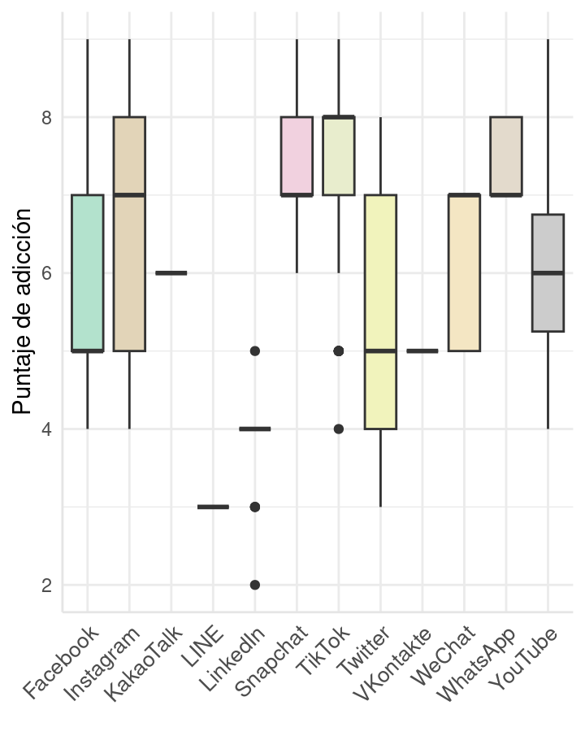

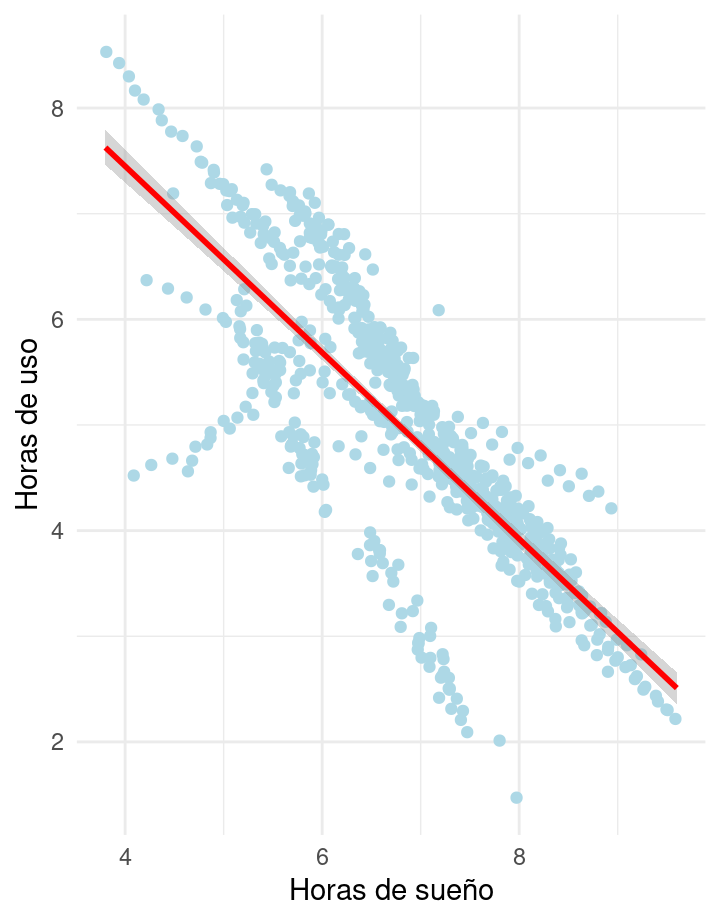

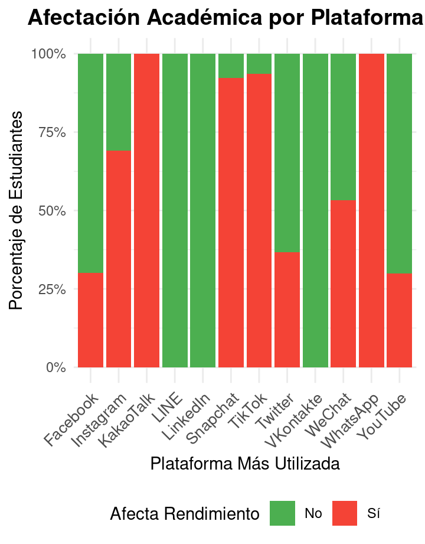

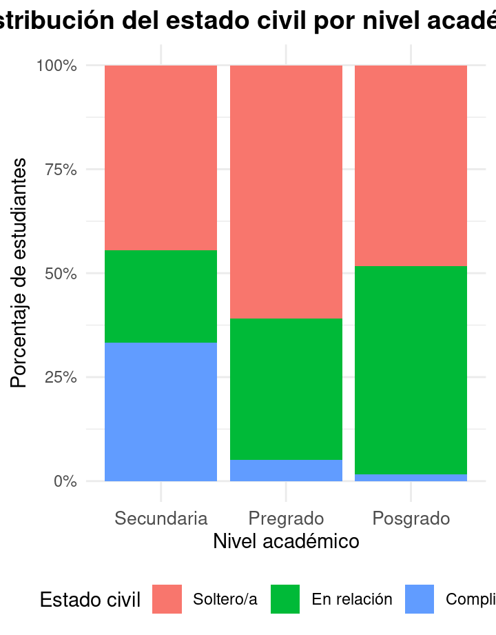

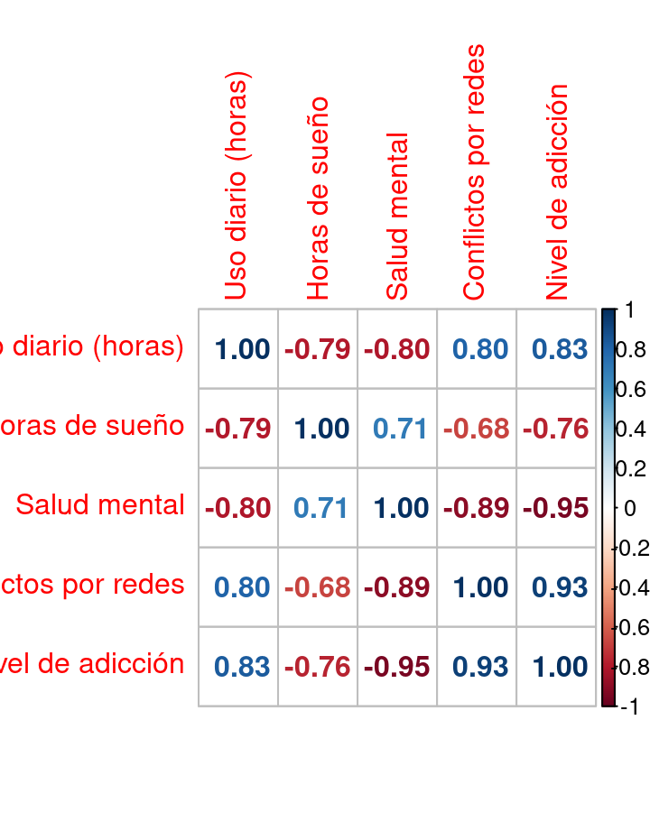

# Descripción General

### **Análisis de Adicción a Redes Sociales en Estudiantes**

**Contexto:** La evolución tecnológica y la facilidad de conexión a internet han tenido un impacto determinante en la población estudiantil. Este estudio analiza los patrones de uso de redes sociales y sus efectos en estudiantes de diferentes niveles educativos.

Estadísticos descriptivos de variables cuantitativas

[output not shown]

### **Descripción**

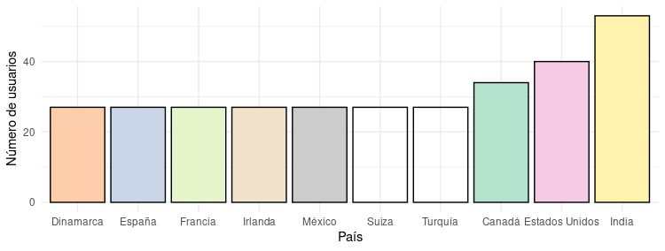

# Uso de Plataformas y Adicción

### **Adicción por Plataforma**

En el gráfico podemos observar que la plataforma que genera mayor adicción en los estudiantes es TikTok, con una mediana de $8$ puntos, seguida de Instagram, Whatsapp, WeChat y Snapchat, todos con una mediana de $7$ puntos. También se evidencia que Snapchat, TikTok y Whatsapp presentan menor variabilidad a diferencia de Instagram y WeChat, cuyas cajas son poco compactas.

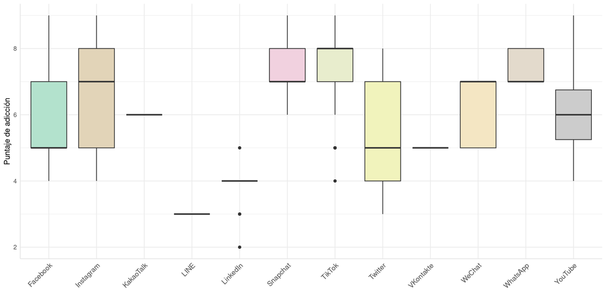

### **Relación entre horas de sueño y uso de redes sociales**

**Interpretación:** La gráfica muestra la relación entre las horas de sueño y las horas promedio de uso de redes sociales entre los estudiantes. Se observa una asociación negativa entre horas de sueño y horas diarias de uso de redes sociales. En promedio, los estudiantes que duermen más tienden a usar menos las redes.

Además, la dispersión de los datos indica que la mayoría de los estudiantes que duermen menos de 6 horas tienden a utilizar redes sociales durante 6 a 8 horas al día. En contraste, quienes duermen más de 7 horas suelen reducir considerablemente su tiempo de uso, ubicándose en un rango aproximado entre 3 y 5 horas.

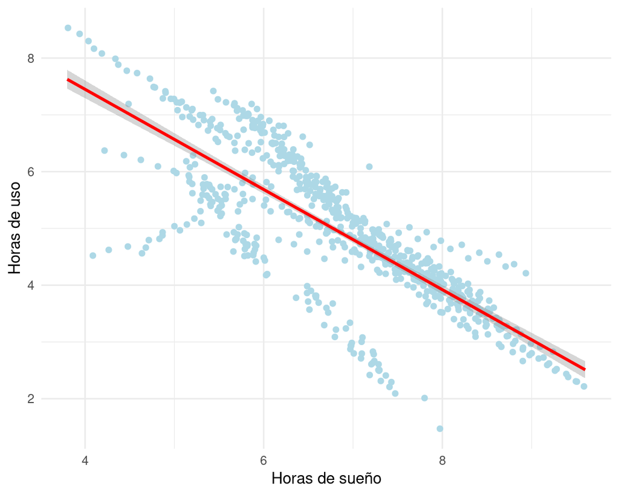

# Impacto en la Salud

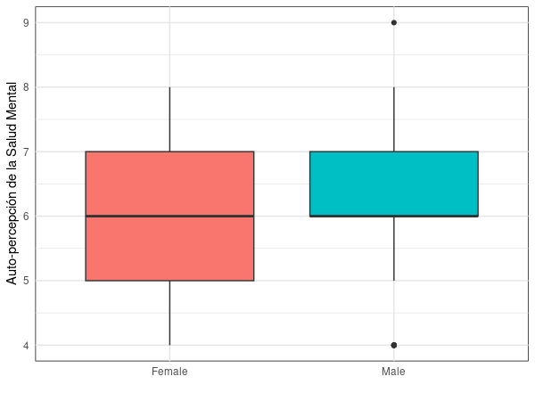

# Impacto Académico

### **Afectación Académica por Plataforma**

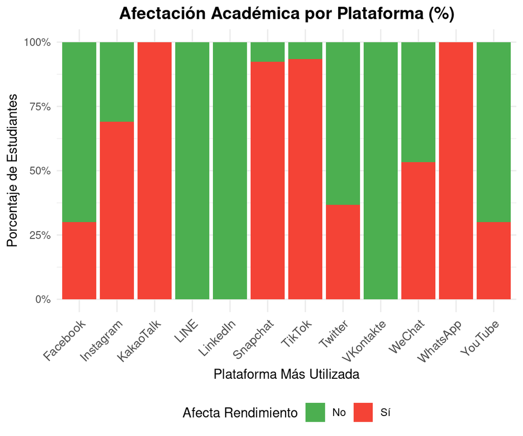

### **Tabla Cruzada: Plataforma vs Afectación Académica**

| Plataforma | No Afecta Frecuencia | No Afecta % | Sí Afecta Frecuencia | Sí Afecta % | Total |
| --- | --- | --- | --- | --- | --- |
| Facebook | 86 | 69.9% | 37 | 30.1% | 123 |
| Instagram | 77 | 30.9% | 172 | 69.1% | 249 |
| KakaoTalk | 0 | 0% | 12 | 100% | 12 |
| LINE | 12 | 100% | 0 | 0% | 12 |
| LinkedIn | 21 | 100% | 0 | 0% | 21 |
| Snapchat | 1 | 7.7% | 12 | 92.3% | 13 |
| TikTok | 10 | 6.5% | 144 | 93.5% | 154 |
| Twitter | 19 | 63.3% | 11 | 36.7% | 30 |
| VKontakte | 12 | 100% | 0 | 0% | 12 |
| WeChat | 7 | 46.7% | 8 | 53.3% | 15 |
| WhatsApp | 0 | 0% | 54 | 100% | 54 |
| YouTube | 7 | 70% | 3 | 30% | 10 |

La tabla muestra las frecuencias absolutas y porcentajes de estudiantes según su plataforma más utilizada y si esta afecta su rendimiento académico. Destacan plataformas como **TikTok (93.5%)**, **WhatsApp (100%)**, **Instagram (69.1%)** y **Snapchat (92.3%)** con alta proporción de afectación académica, mientras que **LinkedIn**, **LINE** y **VKontakte** no muestran impacto negativo en el rendimiento académico.

# Perfil Sociodemográfico

### **Estado civil por nivel académico**

El gráfico muestra la distribución de estudiantes según su estado civil de acuerdo al nivel académico que cada uno de ellos tiene. Con él, se puede destacar que dentro de la población prima el estado civil soltero/a frente al resto.

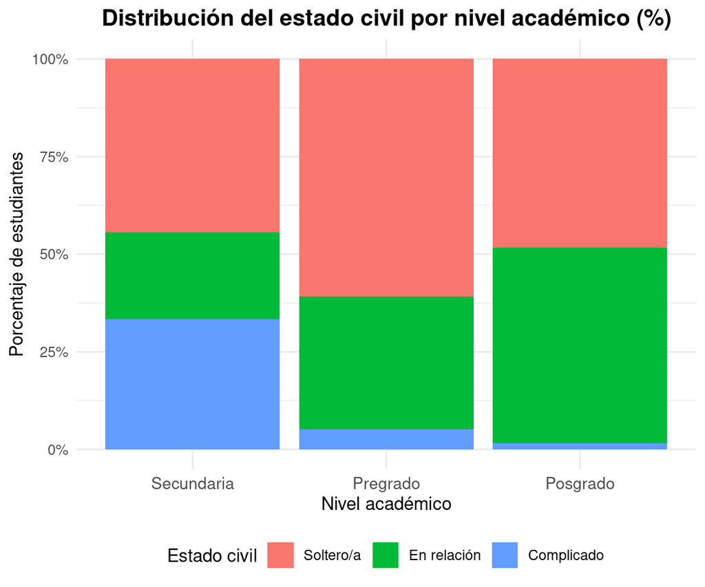

### **Tabla cruzada: nivel académico vs estado civil**

| Nivel académico | Soltero/a Frecuencia | Soltero/a % | En relación Frecuencia | En relación % | Complicado Frecuencia | Complicado % | Total |
| --- | --- | --- | --- | --- | --- | --- | --- |
| Secundaria | 12 | 44.4% | 6 | 22.2% | 9 | 33.3% | 27 |
| Pregrado | 215 | 60.9% | 120 | 34% | 18 | 5.1% | 353 |
| Posgrado | 157 | 48.3% | 163 | 50.2% | 5 | 1.5% | 325 |

La tabla presenta para cada nivel académico los porcentajes de estudiantes en cada estado civil, junto con el total por cada nivel. Esto complementa al gráfico inicialmente presentado, de tal forma que permite ver los valores exactos de cada variable y comparar la distribución del estado civil entre Secundaria, Pregrado y Posgrado.

De lo cual podemos evidenciar que hay una gran frecuencia en los niveles académicos superiores como el pregrado y el posgrado en comparación de los pocos que se pueden visualizar en secundaria. Adicionalmente, se destaca que una pequeña parte la población tiene secundaria como nivel académico y se encuentra en un estado civil complicado.

# Analisis Correlaciones

### **Correlaciones entre las varianbles cuantitativas**

**Contexto:** La evolución tecnológica y la facilidad de conexión a internet han tenido un impacto determinante en la población estudiantil. Este estudio analiza los patrones de uso de redes sociales y sus efectos en estudiantes de diferentes niveles educativos.

### **Matriz de Correlación Cuantitativa**

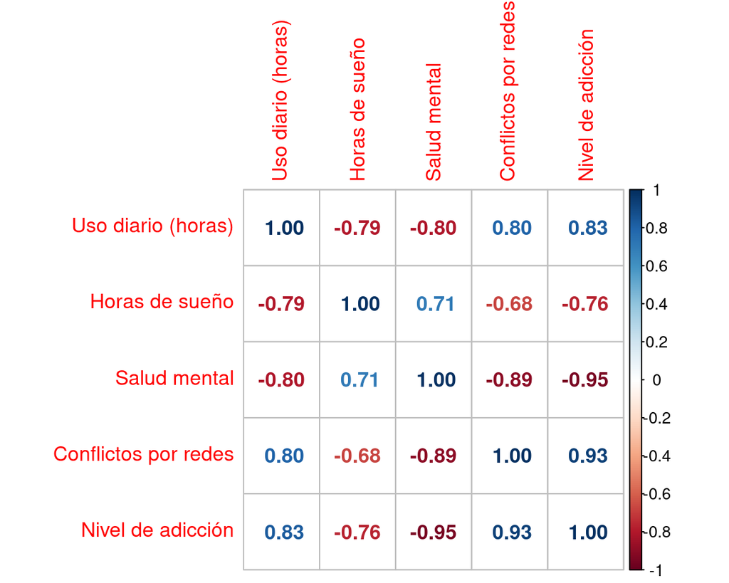